# Lab07_OLS_Template

# Chunk 1- load data and packages

1.1) load datasets `boobies` and `LionNoses` 1.2) load packages `tidyverse` 1.3) describe the structures of each of the datasets. 1.4) using the primary literature, describe what do the data represent?

# Chunk 2- Hypothesis building

2.1) What are the null and alternative STATISTICAL hypotheses being bested by the `boobies` dataset 2.2) What are the null and alternative STATISTICAL hypotheses being bested by the `LionNoses` dataset 2.3) What are the null and alternative BIOLOGICAL hypotheses being bested by the `boobies` dataset 2.4) What are the null and alternative BIOLOGICAL hypotheses being bested by the `LionNoses` dataset

# Chunk 3- Check assumptions- Normallity

3.1) Use a density plot to evaluate how normal the data are for the predictor variables in the boobies and Lion datasets, do these variables look normally distirbuted? -Use, a qq plot and a density plot to visulaly investigate their normality. -Use a `shapiro.test` to statistically ingestigate their normality.

3.2) If you find the data are not normally distributed, how could you normalize these data? Use visual and statistical proof to demonstrate that the data have improved their normallity.

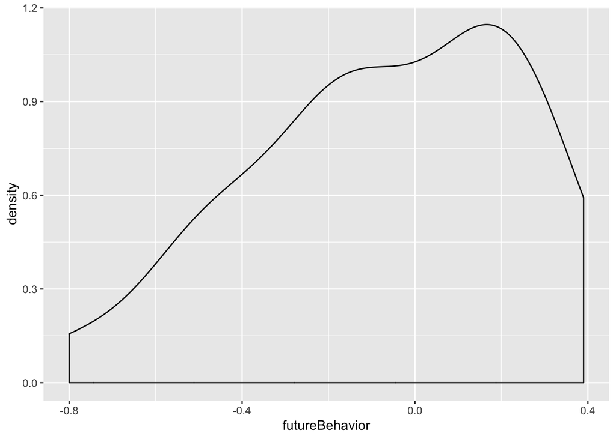

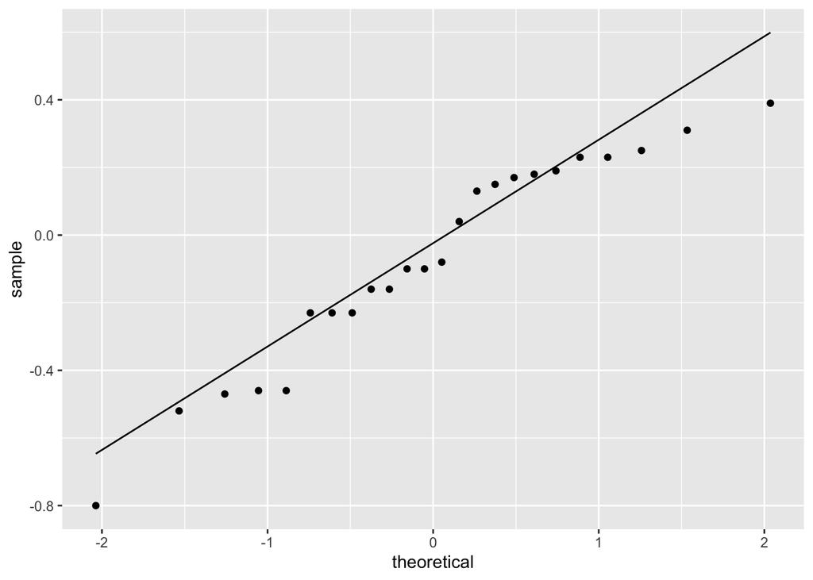

```
##
##  Shapiro-Wilk normality test
##
## data:  boobies$futureBehavior
## W = 0.94258, p-value = 0.1861
```

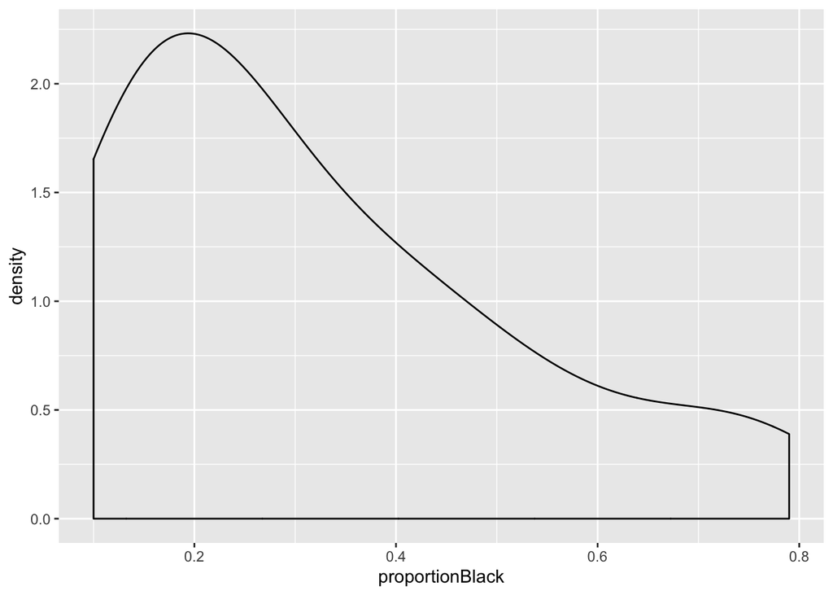

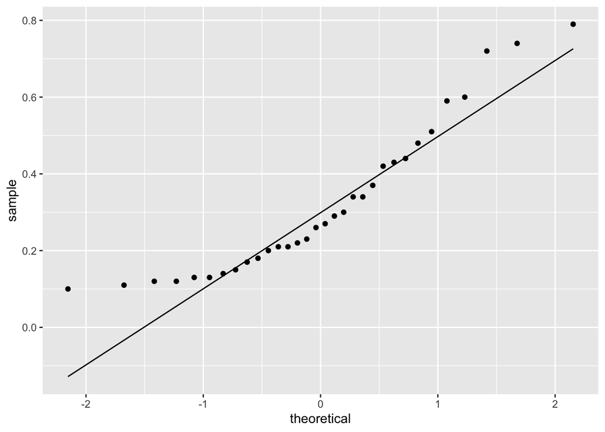

```
##
##  Shapiro-Wilk normality test
##
## data:  Lion$proportionBlack
## W = 0.88895, p-value = 0.003279
```

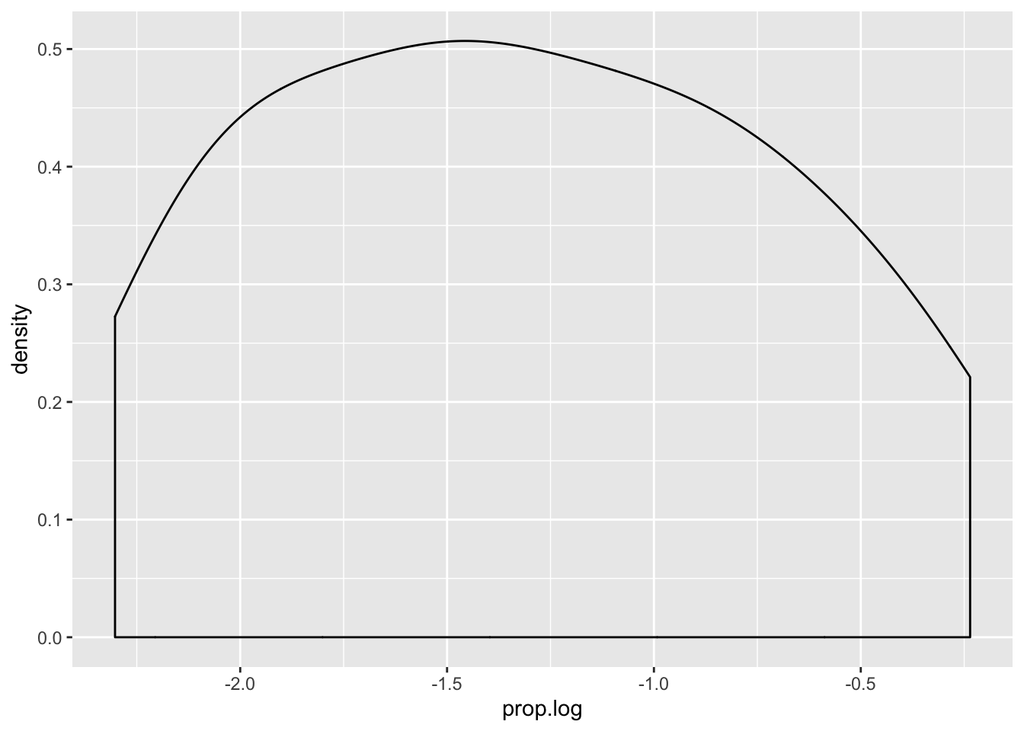

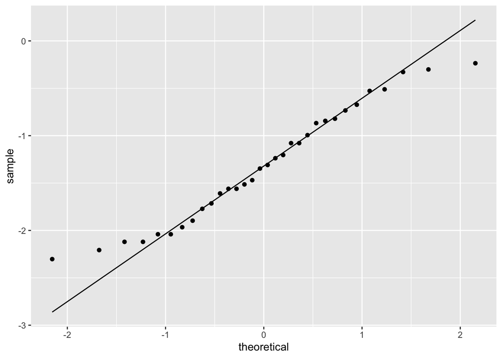

```
##
##  Shapiro-Wilk normality test
##
## data:  Lion$prop.log
## W = 0.95909, p-value = 0.2594
```

# Chunk 4- Plot the scatterplot with best-fit lines

4.1) Plot the relationship beteen the number of nesting visits and their future behavior response

4.2) Plot the relationship between Lion age and the proportion of black on their noses.

4.3) How does the previous plot compare to the transformed response variable?

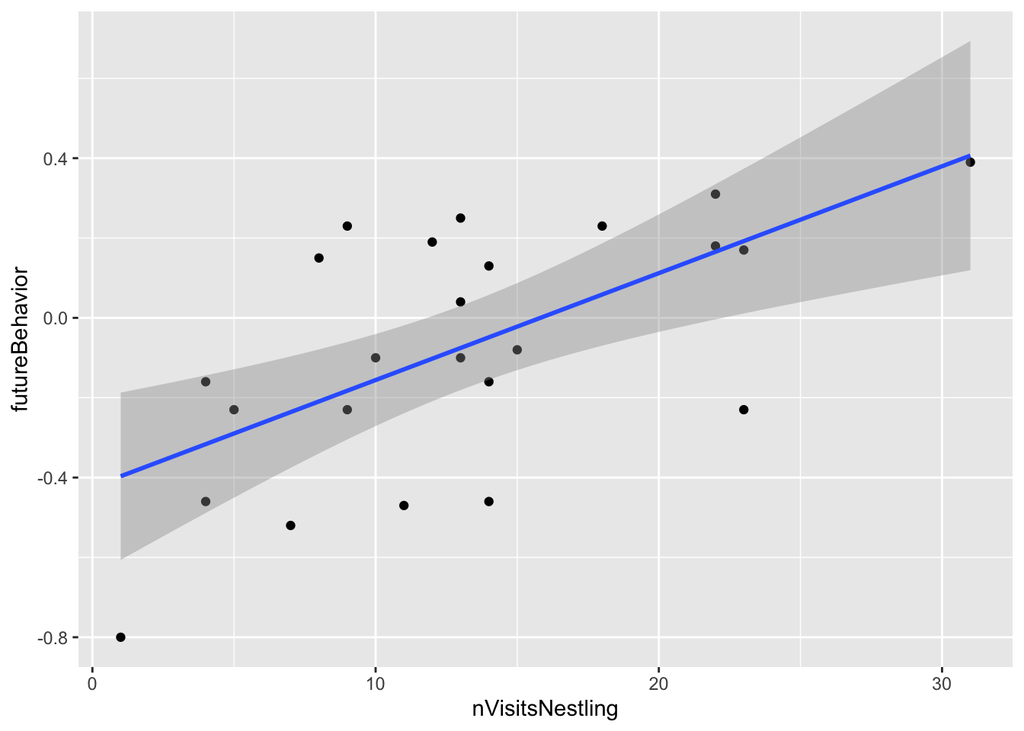

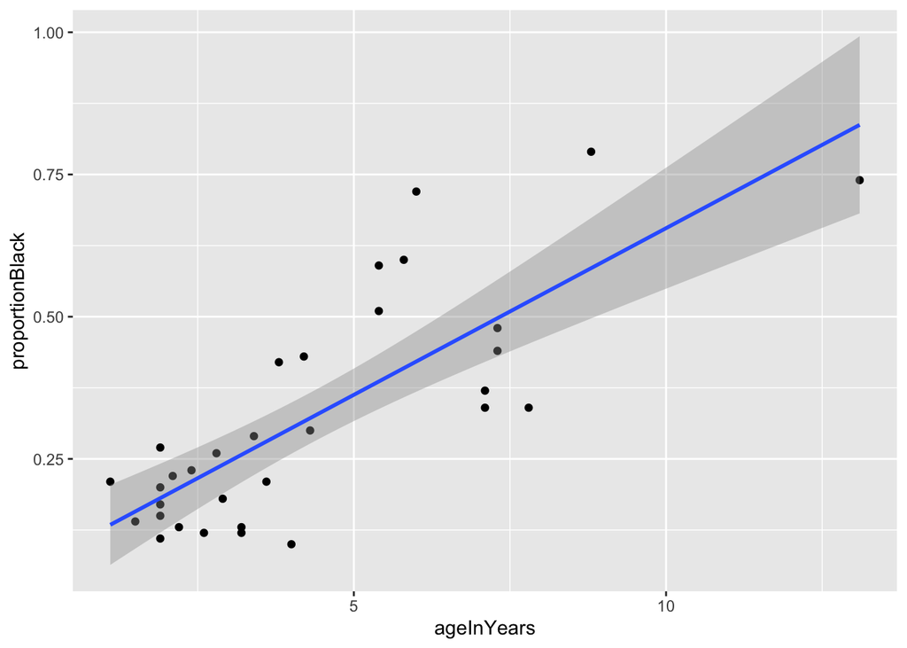

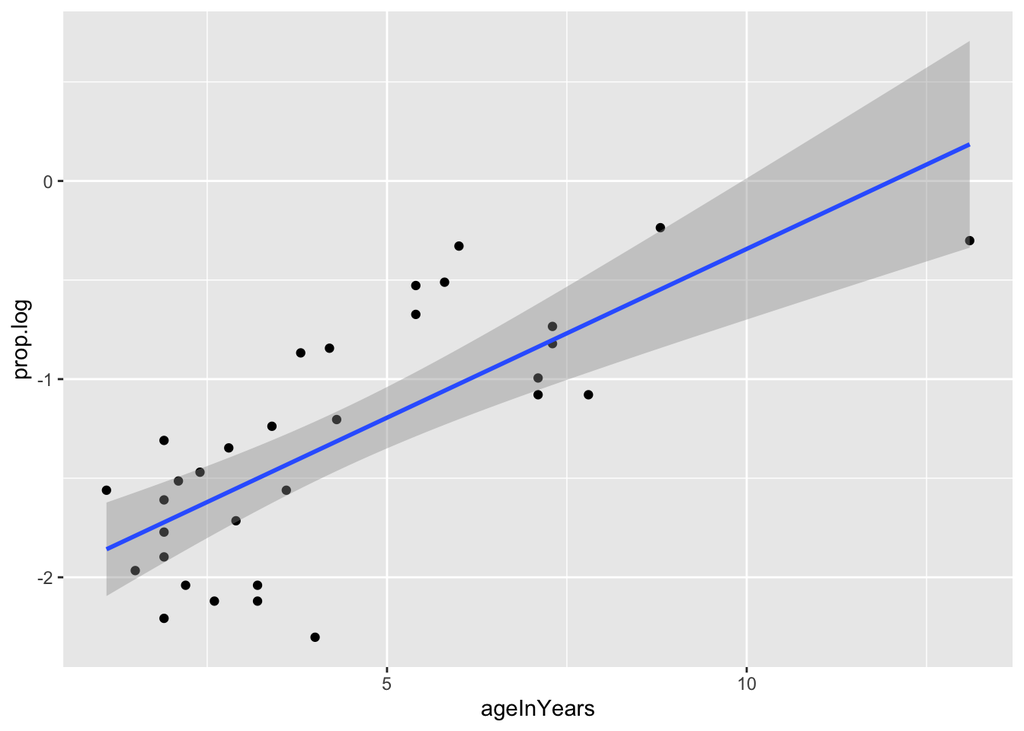

# Chunk 5- Build linear models

5.1) use the `lm` function to create linear model objects for both the untransformed data and the transformed datasets 5.2) what are the R2 values and p values for each of the models? 5.3) what are the coefficients of the linear models?  
5.4)How can these coefficients be interepreted?

```
##
## Call:
## lm(formula = futureBehavior ~ nVisitsNestling, data = boobies)
##
## Residuals:
##      Min       1Q   Median       3Q      Max
## -0.42232 -0.11941 -0.00103  0.16019  0.41253
##
## Coefficients:
##                  Estimate Std. Error t value Pr(>|t|)
## (Intercept)     -0.423507   0.107371  -3.944 0.000691 ***
## nVisitsNestling  0.026775   0.007206   3.716 0.001203 **
## ---
## Signif. codes:  0 '***' 0.001 '**' 0.01 '*' 0.05 '.' 0.1 ' ' 1
##
## Residual standard error: 0.249 on 22 degrees of freedom
## Multiple R-squared:  0.3856, Adjusted R-squared:  0.3577
## F-statistic: 13.81 on 1 and 22 DF,  p-value: 0.001203
```

```
##
## Call:
## lm(formula = proportionBlack ~ ageInYears, data = Lion)
##
## Residuals:
##      Min       1Q   Median       3Q      Max
## -0.20406 -0.07758 -0.01750  0.07913  0.29876
##
## Coefficients:
##             Estimate Std. Error t value Pr(>|t|)
## (Intercept) 0.069696   0.041956   1.661    0.107
## ageInYears  0.058591   0.008307   7.053 7.68e-08 ***
## ---
## Signif. codes:  0 '***' 0.001 '**' 0.01 '*' 0.05 '.' 0.1 ' ' 1
##
## Residual standard error: 0.1238 on 30 degrees of freedom
## Multiple R-squared:  0.6238, Adjusted R-squared:  0.6113
## F-statistic: 49.75 on 1 and 30 DF,  p-value: 7.677e-08
```

```
##
## Call:
## lm(formula = prop.log ~ ageInYears, data = Lion)
##
## Residuals:
##      Min       1Q   Median       3Q      Max
## -0.93774 -0.27175  0.02533  0.30149  0.69571
##
## Coefficients:
##             Estimate Std. Error t value Pr(>|t|)
## (Intercept) -2.04612    0.14059 -14.554  3.9e-15 ***
## ageInYears   0.17032    0.02783   6.119  1.0e-06 ***
## ---
## Signif. codes:  0 '***' 0.001 '**' 0.01 '*' 0.05 '.' 0.1 ' ' 1
##
## Residual standard error: 0.4148 on 30 degrees of freedom
## Multiple R-squared:  0.5552, Adjusted R-squared:  0.5403
## F-statistic: 37.44 on 1 and 30 DF,  p-value: 1.001e-06
```

# Chunk 6: Residuals

6.1) plot the resiudal plots (ie. fitted values vs residual values) 6.2) add a horizontal line at the y=0 value 6.3) Describe the patterns that stand out between the transformed (normal data) and the untransformed raw data

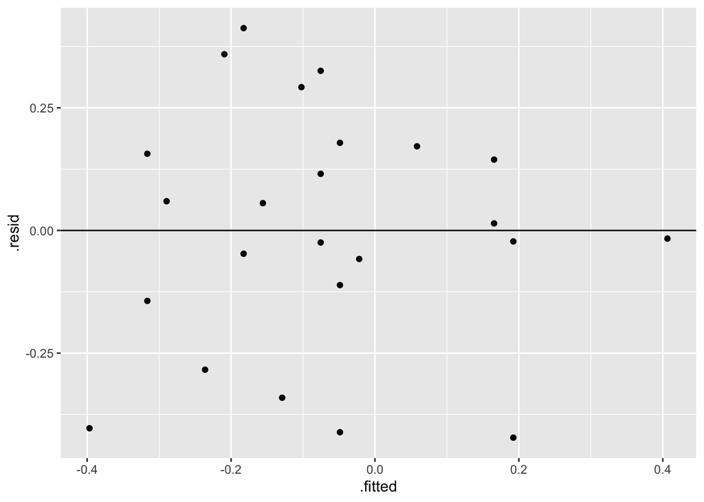

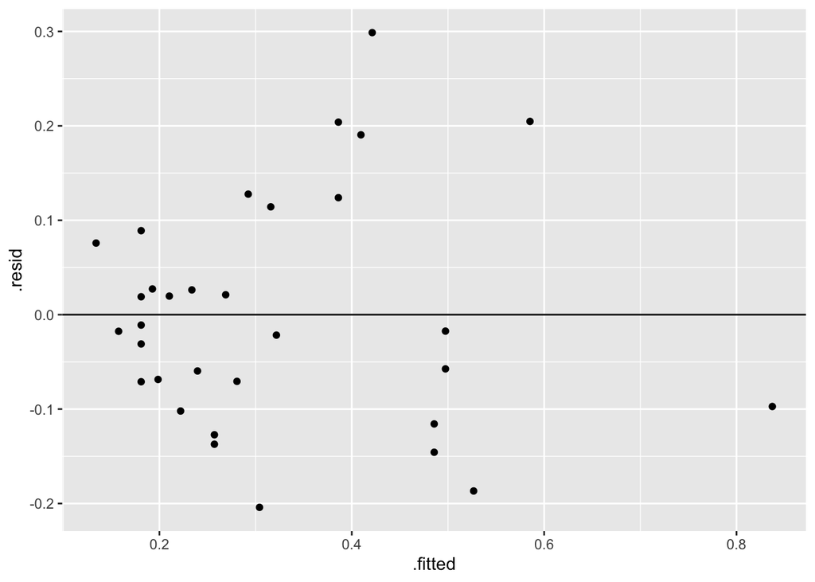

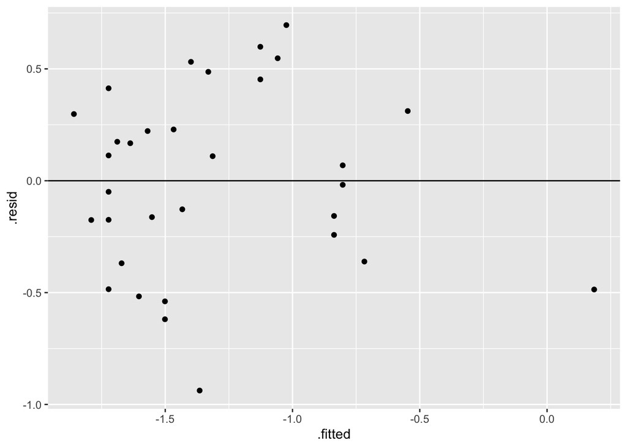